# Practice 02 part 02: Keypoint detection and description

#### 1.2.1 Gaussian and Gaussian derivatives

A [Gaussian function](https://en.wikipedia.org/wiki/Gaussian_function) is a function of the form: $$ f(x) = a e^{-(x-b)^2/(2c^2)} $$ The graph of a Gaussian is a characteristic symmetric "[bell curve](https://en.wikipedia.org/wiki/Normal_distribution)" shape. The parameter $a$ is the height of the curve's peak, $b$ is the position of the center of the peak and $c$ (the [standard deviation](https://en.wikipedia.org/wiki/Standard_deviation)) controls the width of the "bell".

In our case, we have a two-dimensional signal therefore our function has the form: $$f(x,y) = a \exp\left(- \left(\frac{(x-x_o)^2}{2\sigma_X^2} + \frac{(y-y_o)^2}{2\sigma_Y^2} \right)\right).$$

Here the coefficient $a$ is the amplitude, $x_0,y_0$ is the center and $\sigma_x,\sigma_y$ are the $x$ and $y$ spreads of the blob.

In our case, we will define our Gaussian kernel with respect to the size $s$ of the window $w$. We want to have:

- an amplitude ($a$) of $1$;
- a center $x_0,y_0$ at the middle of the window: $(0,0)$;
- a spread $\sigma_x,\sigma_y$ of one third of the size of the window: $(s/3,s/3)$.

The derivatives are easy to compute in our case.

[figure not shown]

**Complete the function below to generate a Gaussian kernel.** Tips: - Do no worry about scaling factors for kernels as they will be scaled automatically during the convolution process. - Make sure to check the documentation of [`np.mgrid`](https://docs.scipy.org/doc/numpy/reference/generated/numpy.mgrid.html) which generates a grid of coordinates.

```python
# Run me!
np.mgrid[-1:1+1,-1:1+1]
```

```
array([[[-1, -1, -1],
        [ 0,  0,  0],
        [ 1,  1,  1]],

       [[-1,  0,  1],
        [-1,  0,  1],
        [-1,  0,  1]]])
```

Tip: you have to implement this:

$$g(x,y) = \exp\left(- \left(\frac{(x)^2}{2\sigma_X^2} + \frac{(y)^2}{2\sigma_Y^2} \right)\right)$$

with $$\sigma_X = \sigma_Y = \frac{1}{3} \text{size}$$

```python
# TODO complete the code of this function
def gauss_kernel(size: int) -> np.array:
    """
    Returns a 2D Gaussian kernel for convolutions.

    Parameters
    ----------
    size: int
        Size of the kernel to build

    Returns
    -------
    kernel: np.array of shape (size, size) and dtype np.float32
        Resulting Gaussian kernel where kernel[i,j] = Gaussian(i, j, mu=(0,0), sigma=(size/3, size/3))
    """
    size = int(size)
    y, x = np.mgrid[-size:size+1, -size:size+1]

    # x and y coefficients of a 2D gaussian with standard dev half of size
    # (ignore scale factor)

    # FIXME this is a box filter, adapt it to be a Gaussian
    # (this would also work, but would lead to poorer performance)
    g = np.ones((size*2+1, size*2+1))

    return g
```

```python
# prof
def gauss_kernel(size: int, sizey: int=None) -> np.array:
    """
    Returns a 2D Gaussian kernel for convolutions.

    Parameters
    ----------
    size: int
        Size of the kernel to build

    Returns
    -------
    kernel: np.array of shape (size, size) and dtype np.float32
        Resulting Gaussian kernel where kernel[i,j] = Gaussian(i, j, mu=(0,0), sigma=(size/3, size/3))
    """
    size = int(size)
    sizey = int(sizey) if sizey is not None else size
    y, x = np.mgrid[-size:size+1, -sizey:sizey+1]

    # x and y coefficients of a 2D gaussian with standard dev half of size
    # (ignore scale factor)
    g = np.exp(-(x**2/(2*(0.33*size)**2)+y**2/(2*(0.33*sizey)**2)))
    return g
```

Let us quickly display this kernel to check its shape. We are looking for something which looks like this, ie a maximal response at the center of the window, then a smooth decrease toward the borders of the window where we have values close to 0:

[figure not shown]

```python
# Run this cell
from mpl_toolkits.mplot3d import Axes3D
```

```
(11, 11) (11, 11) (11, 11)
```

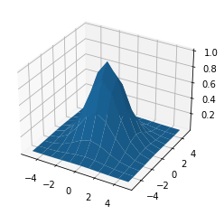

```python
# Run this cell
wsize = 5
Y,X = np.mgrid[-wsize:wsize+1,-wsize:wsize+1]
Z = gauss_kernel(wsize)
print(X.shape, Y.shape, Z.shape)
# print(Z)
fig = plt.figure()
ax = fig.add_subplot(111, projection='3d')
ax.plot_surface(X, Y, Z);
```

[figure not shown]

**Complete the function below to generate two Gaussian derivative kernels, then plot them.** Tips: - Do no worry about scaling factors for kernels as they will be scaled automatically during the convolution process. - It **really** looks like the previous one.

We are looking for Gaussian derivatives which look like this:

[figure not shown]

```python
from typing import Tuple
```

```python
# TODO complete this function
def gauss_derivative_kernels(size: int) -> Tuple[np.array, np.array]:
    """
    Returns two 2D Gaussian derivative kernels (x and y) for convolutions.

    Parameters
    ----------
    size: int
        Size of the kernels to build

    Returns
    -------
    (gx, gy): tupe of (np.array, np.array), each of shape (size, size) and dtype np.float32
        Resulting Gaussian kernels where kernel[i,j] = Gaussian_z(i, j, mu=(0,0), sigma=(size/3, size/3))
        where Gaussian_z is either the x or the y Gaussian derivative.
    """
    size = int(size)
    y, x = np.mgrid[-size:size+1, -size:size+1]

    #x and y derivatives of a 2D gaussian with standard dev half of size
    # (ignore scale factor)
    gx = np.ones((size*2+1, size*2+1))  # FIXME
    gy = np.ones((size*2+1, size*2+1))  # FIXME

    return gx,gy
```

```python
# prof
def gauss_derivative_kernels(size: int, sizey: int=None) -> Tuple[np.array, np.array]:
    """
    Returns two 2D Gaussian derivative kernels (x and y) for convolutions.

    Parameters
    ----------
    size: int
        Size of the kernels to build

    Returns
    -------
    (gx, gy): tupe of (np.array, np.array), each of shape (size, size) and dtype np.float32
        Resulting Gaussian kernels where kernel[i,j] = Gaussian_z(i, j, mu=(0,0), sigma=(size/3, size/3))
        where Gaussian_z is either the x or the y Gaussian derivative.
    """
    size = int(size)
    sizey = int(sizey) if sizey is not None else size
    y, x = np.mgrid[-size:size+1, -sizey:sizey+1]

    #x and y derivatives of a 2D gaussian with standard dev half of size
    # (ignore scale factor)
    gx = - x * np.exp(-(x**2/(2*(0.33*size)**2)+y**2/(2*(0.33*sizey)**2)))
    gy = - y * np.exp(-(x**2/(2*(0.33*size)**2)+y**2/(2*(0.33*sizey)**2)))

    return gx,gy
```

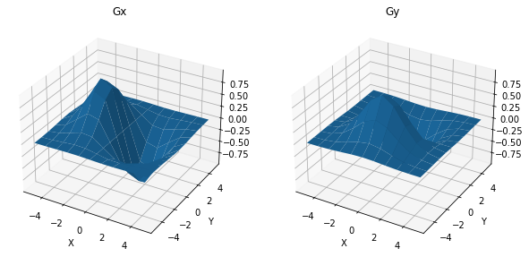

```python
# Run this cell
# Plot gx and gy
wsize = 5
Y,X = np.mgrid[-wsize:wsize+1,-wsize:wsize+1]
Gx, Gy = gauss_derivative_kernels(wsize)
fig = plt.figure(figsize=(10,5))
ax = fig.add_subplot(121, projection='3d')
ax.plot_surface(X, Y, Gx)
ax.set_title("Gx")
ax.set_xlabel("X")
ax.set_ylabel("Y")
ax = fig.add_subplot(122, projection='3d')
ax.plot_surface(X, Y, Gy)
ax.set_title("Gy")
ax.set_xlabel("X")
ax.set_ylabel("Y");
```

[figure not shown]

**Complete the function below to compute $I_x$ and $I_y$.** Tips: - Use `scipy.signal.convolve` to apply the kernels. - Make sure the target image has the **same** size as the original image.

```python
from scipy import signal
signal.convolve?
```

```python
# TODO complete this function
def gauss_derivatives(im: np.array, size: int) -> Tuple[np.array, np.array]:
    """
    Returns x and y gaussian derivatives for a given image.

    Parameters
    ----------
    im: np.array of shape (rows, cols)
        Input image
    size: int
        Size of the kernels to use

    Returns
    -------
    (Ix, Iy): tupe of (np.array, np.array), each of shape (rows, cols)
        Derivatives (x and y) of the image computed using Gaussian derivatives (with kernel of size `size`).
    """
    gx,gy = gauss_derivative_kernels(size)

    imx = np.zeros_like(im)  # FIXME
    imy = np.zeros_like(im)  # FIXME

    return imx,imy
```

```python
# prof
def gauss_derivatives(im: np.array, size: int, sizey: int=None) -> Tuple[np.array, np.array]:
    """
    Returns x and y gaussian derivatives for a given image.

    Parameters
    ----------
    im: np.array of shape (rows, cols)
        Input image
    size: int
        Size of the kernels to use

    Returns
    -------
    (Ix, Iy): tupe of (np.array, np.array), each of shape (rows, cols)
        Derivatives (x and y) of the image computed using Gaussian derivatives (with kernel of size `size`).
    """
    gx,gy = gauss_derivative_kernels(size, sizey=sizey)

    imx = signal.convolve(im, gx, mode='same')
    imy = signal.convolve(im, gy, mode='same')

    return imx,imy
```

[figure not shown]

**Load some bubble images and show their derivatives.** Tips: - Make sure you compute derivatives on the grayscale image. - A filter of size $3$ will be used lated.

```python
# Some Jupyter magic to help you
# This creates a SORTED list of files to process.
bubble_files = !ls $PATH_TO_RESOURCES/bubbles_200dpi/b*.png | sort
bubble_files[:3]
```

```
['/home/jchazalo/git/jchazalo/cours-mlrf-preparation/resources/twin_it/bubbles_200dpi/b001.png',
 '/home/jchazalo/git/jchazalo/cours-mlrf-preparation/resources/twin_it/bubbles_200dpi/b002.png',
 '/home/jchazalo/git/jchazalo/cours-mlrf-preparation/resources/twin_it/bubbles_200dpi/b003.png']
```

```python
# load all the bubbles
bubbles = [cv2.imread(ff) for ff in bubble_files]
# list of bubbles (np.array) in grayscale
bubbles_gray = [cv2.cvtColor(bb, cv2.COLOR_BGR2GRAY) for bb in bubbles]
```

[figure not shown]

```python
# (just run this cell)
# Display some bubbles and their derivatives

# Let us save time
def imbgr2rgb(img):
    return cv2.cvtColor(img, cv2.COLOR_BGR2RGB)

num_bb = 5
plt.figure(figsize=(8,10))
for bb_id in range(num_bb):
    bb = bubbles[bb_id]
    bb_gray = bubbles_gray[bb_id]
    bb_x, bb_y = gauss_derivatives(bb_gray, 3)
    plt.subplot(num_bb,3,1+3*bb_id)
    plt.imshow(imbgr2rgb(bb))
    plt.axis("off")
    plt.title("$I$: bb_%d" % bb_id)
    plt.subplot(num_bb,3,2+3*bb_id)
    plt.imshow(bb_x)
    plt.colorbar(shrink=0.5)
    plt.axis("off")
    plt.title("$I_x$")
    plt.subplot(num_bb,3,3+3*bb_id)
    plt.imshow(bb_y)
    plt.colorbar(shrink=0.75)
    plt.axis("off")
    plt.title("$I_y$")
```

#### 1.2.2 Harris response

We can now compute the Harris response of an image.

[figure not shown]

```python
# TODO complete this function
def compute_harris_response(image: np.array) -> np.array:
    """
    Returns the Harris cornerness response of a given image.

    Parameters
    ----------
    im: np.array of shape (rows, cols)
        Input image

    Returns
    -------
    response: np.array of shape (rows, cols) and dtype np.float32
        Harris cornerness response image.
    """
    DERIVATIVE_KERNEL_SIZE = 1  # FIXME try different values here
    OPENING_SIZE = 1  # FIXME try different values here

    #derivatives
    imx,imy = gauss_derivatives(image, DERIVATIVE_KERNEL_SIZE)

    #kernel for weighted sum
    gauss = gauss_kernel(OPENING_SIZE) # opening param

    #compute components of the structure tensor
    Wxx = np.zeros_like(image)  # FIXME
    Wxy = np.zeros_like(image)  # FIXME
    Wyy = np.zeros_like(image)  # FIXME

    #determinant and trace
    Wdet = np.zeros_like(image)  # FIXME
    Wtr = np.zeros_like(image)  # FIXME

    # return Wdet - k * Wtr**2 # k is hard to tune
    # return Wdet / Wtr # we would need to filter NaNs
    return Wdet / (Wtr + 1)  # 1 seems to be a reasonable value for epsilon
```

```python
# prof
def compute_harris_response(image):  #, k=0.05):
    """
    Returns the Harris cornerness response of a given image.

    Parameters
    ----------
    im: np.array of shape (rows, cols)
        Input image

    Returns
    -------
    response: np.array of shape (rows, cols) and dtype np.float32
        Harris cornerness response image.
    """
    DERIVATIVE_KERNEL_SIZE = 3
    OPENING_SIZE = 3

    #derivatives
    imx,imy = gauss_derivatives(image, DERIVATIVE_KERNEL_SIZE)

    #kernel for weighted sum
    gauss = gauss_kernel(OPENING_SIZE) # opening param

    #compute components of the structure tensor
    Wxx = signal.convolve(imx*imx,gauss, mode='same')
    Wxy = signal.convolve(imx*imy,gauss, mode='same')
    Wyy = signal.convolve(imy*imy,gauss, mode='same')

    #determinant and trace
    Wdet = Wxx*Wyy - Wxy**2
    Wtr = Wxx + Wyy
#     print(Wdet.min(), Wdet.max(), Wdet.mean())
#     print(Wtr.min(), Wtr.max(), Wtr.mean())

    # return Wdet - k * Wtr**2 # k is hard to tune
    # return Wdet / Wtr # we would need to filter NaNs
    return Wdet / (Wtr + 1)  # 1 seems to be a reasonable value for epsilon
```

[figure not shown]

```python
# display some bubbles and their Harris response, showing the scale of values
num_bb = 5
plt.figure(figsize=(12,10))
for bb_id in range(num_bb):
    bb = bubbles[bb_id]
    bb_gray = bubbles_gray[bb_id]
    bb_x, bb_y = gauss_derivatives(bb_gray, 4)
    bb_h = compute_harris_response(bb_gray)
    plt.subplot(num_bb,4,1+4*bb_id)
    plt.imshow(imbgr2rgb(bb))
    plt.axis("off")
    plt.title("$I$: bb_%d" % bb_id)
    plt.subplot(num_bb,4,2+4*bb_id)
    plt.imshow(bb_x)
    plt.colorbar(shrink=0.5)
    plt.axis("off")
    plt.title("$I_x$")
    plt.subplot(num_bb,4,3+4*bb_id)
    plt.imshow(bb_y)
    plt.colorbar(shrink=0.75)
    plt.axis("off")
    plt.title("$I_y$")
    plt.subplot(num_bb,4,4+4*bb_id)
    plt.imshow(bb_h)
    plt.colorbar(shrink=0.75)
    plt.axis("off")
    plt.title("Harris resp.")
```

## 1.3 Identify corners among the maximas

Now we have computed the "cornerness map" of an image, we have to select the best corner candidates. The full process for selecting keypoints (ie coordinates of corners) can be decomposed in:

1. compute the Harris corner response map;
2. create a mask to select best keypoints and reject the ones which are too close from the border of the image **or of the bubble** (more details below);
3. perform a non-maximal suppression (ignore elements which are not local maximas);
4. sort the candidates based on their response value.

The masking step is a bit special in our case because our bubbles have an artificial boundary inside the image which can cause keypoints to be detected. We want to reject keypoints which are too close from the bubble boundary to avoid this. To save you time, we provide you with a simple function `bubble2maskeroded` which takes a bubble and returns a mask which removes the border of the bubble.

```python
# RUN ME
# mathematical morphology magic: this returns an eroded (shrunk) mask
def bubble2maskeroded(img_gray: np.array, border: int=10) -> np.array:
    """
    Returns the eroded mask of a given image, to remove pixels which are close to the border.

    Parameters
    ----------
    im: np.array of shape (rows, cols)
        Input image

    Returns
    -------
    mask: np.array of shape (rows, cols) and dtype bool
        Image mask.
    """
    if img_gray.ndim > 2:
        raise ValueError(
            """bubble2maskeroded: img_gray must be a grayscale image.
            The image you passed has %d dimensions instead of 2.
            Try to convert it to grayscale before passing it to bubble2maskeroded.
            """ % (img_gray.ndim, ))
    mask = img_gray > 0
    kernel = cv2.getStructuringElement(cv2.MORPH_ELLIPSE, (border*2,border*2))
    # new: added a little closing below because some bubbles have some black pixels inside
    mask_er = cv2.morphologyEx(mask.astype(np.uint8), cv2.MORPH_CLOSE, np.ones((3,3)))
    mask_er = cv2.erode(mask.astype(np.uint8),
                        kernel,
                        borderType=cv2.BORDER_CONSTANT,
                        borderValue=0)
    return mask_er > 0
```

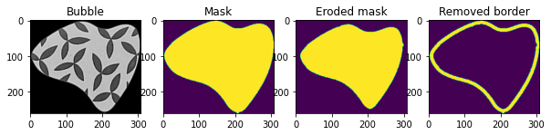

```python
# RUN ME
# bubble2maskeroded demo
bb_id = 5
plt.figure(figsize=(10,4))
plt.subplot(141)
plt.imshow(bubbles_gray[bb_id], cmap='gray')
plt.axis('on'); plt.title("Bubble");
plt.subplot(142)
plt.imshow(bubbles_gray[bb_id] > 0)
plt.axis('on'); plt.title("Mask");
plt.subplot(143)
plt.imshow(bubble2maskeroded(bubbles_gray[bb_id]))
plt.axis('on'); plt.title("Eroded mask");
plt.subplot(144)
plt.imshow((bubbles_gray[bb_id] > 0) & np.logical_not(bubble2maskeroded(bubbles_gray[bb_id])))
plt.axis('on'); plt.title("Removed border");
```

[figure not shown]

**Complete the function below to build a complete Harris corner detector.** Tips: - Prepare the debug visualization first to check intermediate results progressively. - Check the mask being created in particular. - Check the documentation of `np.nonzero` and try it separately. - Use `np.argsort` to sort values.

```python
# prof
# What follows is a breakdown of the different parts of the detection, given some Harris response map
```

```python
# prof
# Masking
image_gray = bubbles_gray[bb_id]
harrisim = compute_harris_response(image_gray)

# 2. Masking
#find top corner candidates above a threshold
threshold=0.1
corner_threshold = harrisim.max() * threshold
harrisim_mask = harrisim > corner_threshold
# apply the mask to ignore the bubble contours and image borders
min_distance=10
harrisim_mask &= bubble2maskeroded(image_gray, border=min_distance)
```

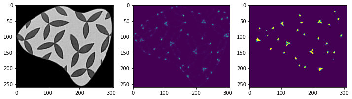

```python
# prof
plt.figure(figsize=(12,8))
plt.subplot(131)
plt.imshow(image_gray, cmap="gray")
plt.subplot(132)
plt.imshow(harrisim)
plt.subplot(133)
plt.imshow(harrisim_mask)
```

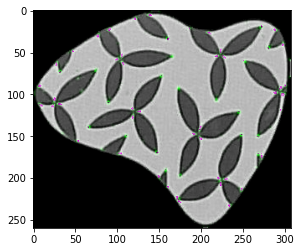

```python
# prof
# responses overlaid on the image
diplay_image = np.dstack((image_gray, np.uint8(image_gray+np.abs(harrisim)/harrisim.max()*255), image_gray))
plt.imshow(diplay_image)
```

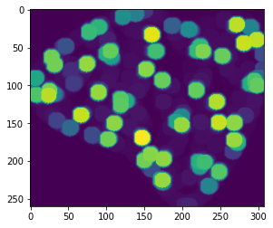

```python
# prof
# illustration of the dilation used for NMS (non-maximal suppression):
# we propagate the value of a local maxima to its neighborhood,
# as we will later keep only the single maximal point in each of these neighborhoods
dil = cv2.dilate(harrisim, cv2.getStructuringElement(cv2.MORPH_ELLIPSE, (20, 20)))
# Pro tip: if we have several maxima with exactly the same value, we can add a small noise to make one of them win
plt.imshow(dil)
```

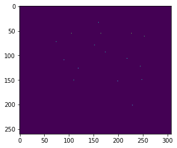

```python
# prof
detect = (np.isclose(dil, harrisim)  # keep only local maximas
          & (harrisim > harrisim.min()+0.5*(harrisim.max()-harrisim.min())) # response threshold
          & bubble2maskeroded(image_gray, border=min_distance))  # bg and border removal
plt.imshow(detect)
```

```python
# prof
# this thansposition is just a way to get the coordinates in the right format
filtered_coords = np.transpose(detect.nonzero())
filtered_coords[:10]
```

```
array([[ 33, 160],
       [ 55, 105],
       [ 55, 165],
       [ 55, 227],
       [ 61, 253],
       [ 72,  74],
       [ 79, 152],
       [ 93, 174],
       [106, 218],
       [109,  90]])
```

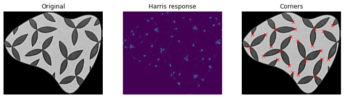

```python
# prof
# and so we get these nice detections
plt.figure(figsize=(12,8))
plt.subplot(131)
plt.imshow(image_gray, cmap="gray")
plt.axis("off")
plt.title("Original")

plt.subplot(132)
plt.imshow(harrisim)
plt.axis("off")
plt.title("Harris response")

plt.subplot(133)
plt.imshow(image_gray, cmap='gray')
plt.plot(filtered_coords[:,1], filtered_coords[:,0], 'x', c='r')
plt.axis("off")
plt.title("Corners")
```

```python
# TODO complete this function
def detect_harris_points(image_gray: np.array, max_keypoints: int=30,
                         min_distance: int=25, threshold: float=0.5) -> np.array:
    """
    Detects and returns a sorted list of coordinates for each corner keypoint detected in an image.

    Parameters
    ----------
    image_gray: np.array
        Input image
    max_keypoints: int, default=30
        Number of keypoints to return, at most (we may have less keypoints)
    min_distance: int, default=25
        Minimum distance between two keypoints
    threshold: float, default=0.1
        For each keypoint k_i, we ensure that its response h_i will verify
        $h_i > min(response) + threshold * (max(reponse) - min(response))$

    Returns
    -------
    corner_coord: np.array of shape (N, 2) and dtype int
        Array of corner keypoint 2D coordinates, with N <= max_keypoints
    """
    # 1. Compute Harris corner response
    harris_resp = compute_harris_response(image_gray)

    # 2. Filtering
    # 2.0 Mask init: all our filtering is performed using a mask
    detect_mask = np.ones(harris_resp.shape, dtype=bool)
    # 2.1 Background and border removal
    detect_mask &= bubble2maskeroded(image_gray, border=min_distance)
    # 2.2 Response threshold
    detect_mask &= True  # FIXME <------------------------  # remove low response elements
    # 2.3 Non-maximal suppression
    # dil is an image where each local maxima value is propagated to its neighborhood (display it!)
    dil = cv2.dilate(harris_resp, cv2.getStructuringElement(cv2.MORPH_ELLIPSE, (min_distance, min_distance)))
    # we want to keep only elements which are local maximas in their neighborhood
    detect_mask &= True  # FIXME <------------ # keep only local maximas by comparing dil and harris_resp

    # 3. Select, sort and filter candidates
    # get coordinates of candidates
    candidates_coords = np.transpose(detect_mask.nonzero())
    # ...and their values
    candidate_values = harris_resp[detect_mask]
    # sort candidates
    sorted_indices = None # FIXME <----------------------
    # keep only the bests
    best_corners_coordinates = candidates_coords  # FIXME <-----------------------

    return best_corners_coordinates
```

```python
# prof
def detect_harris_points(image_gray: np.array, max_keypoints: int=30,
                         min_distance: int=25, threshold: float=0.1) -> np.array:
    """
    Detects and returns a sorted list of coordinates for each corner keypoint detected in an image.

    Parameters
    ----------
    image_gray: np.array
        Input image
    max_keypoints: int, default=30
        Number of keypoints to return, at most (we may have less keypoints)
    min_distance: int, default=25
        Minimum distance between two keypoints
    threshold: float, default=0.1
        For each keypoint k_i, we ensure that its response h_i will verify
        $h_i > min(response) + threshold * (max(reponse) - min(response))$

    Returns
    -------
    corner_coord: np.array of shape (N, 2) and dtype int
        Array of corner keypoint 2D coordinates, with N <= max_keypoints
    """
    # 1. Compute Harris corner response
    harris_resp = compute_harris_response(image_gray)

    # 2. Filtering
    # 2.0 Mask init: all our filtering is performed using a mask
    detect_mask = np.ones(harris_resp.shape, dtype=bool)
    # 2.1 Background and border removal
    detect_mask &= bubble2maskeroded(image_gray, border=min_distance)
    # 2.2 Response threshold
    detect_mask &= harris_resp > harris_resp.min()+threshold*(harris_resp.max()-harris_resp.min())
    # 2.3 Non-maximal suppression
    dil = cv2.dilate(harris_resp, cv2.getStructuringElement(cv2.MORPH_ELLIPSE, (min_distance, min_distance)))
    detect_mask &= np.isclose(dil, harris_resp)  # keep only local maximas

    # 3. Select, sort and filter candidates
    # get coordinates of candidates
    candidates_coords = np.transpose(detect_mask.nonzero())
    # ...and their values
    candidate_values = harris_resp[detect_mask]
    #sort candidates
    sorted_indices = np.argsort(candidate_values)
    # keep only the bests
    best_corners_coordinates = candidates_coords[sorted_indices][:max_keypoints]

    return best_corners_coordinates
```

```python
# prof (old, pre-2022 version, without the elegant NMS – don't use it)
# def detect_harris_points(image_gray, min_distance=25, threshold=0.1):
#     """ detect and return corners from a grayscale image
#         min_distance is the minimum nbr of pixels separating
#         corners and image boundary

#         returns a list of (x,y) coordinates of corners.
#         """
#     # 1. Compute Harris corner response
#     harrisim = compute_harris_response(image_gray)

#     # 2. Masking
#     #find top corner candidates above a threshold
#     corner_threshold = harrisim.max() * threshold
#     harrisim_mask = harrisim > corner_threshold
#     # apply the mask to ignore the bubble contours and image borders
#     harrisim_mask &= bubble2maskeroded(image_gray, border=min_distance)
#     # filter the borders (useless thanks to previous line)
# #     harrisim_mask[:min_distance,:] = False   # Top border
# #     harrisim_mask[-min_distance:,:] = False  # Bottom border
# #     harrisim_mask[:,:min_distance] = False  # Left border
# #     harrisim_mask[:,-min_distance:] = False  # Right border

#     # 3. Candidate pre-selection and sorting
#     #get coordinates of candidates
#     candidates = harrisim_mask.nonzero()
#     coords = np.transpose(candidates)
#     #...and their values
#     candidate_values = harrisim[candidates]

#     #sort candidates
#     index = np.argsort(candidate_values)

#     # 4. Max filter over neighborhood
#     #select the best points taking min_distance into account
#     filtered_coords = []
#     for i in index:
#         if harrisim_mask[coords[i][0]][coords[i][1]]:
#             filtered_coords.append(coords[i])
#             # update the mask to prevent neighbors from being selected
#             harrisim_mask[max(0, coords[i][0]-min_distance):
#                           min(coords[i][0]+min_distance, harrisim_mask.shape[0]),
#                           max(0, coords[i][1]-min_distance):
#                           max(coords[i][1]+min_distance, harrisim_mask.shape[1])] = False

#     return np.array(filtered_coords)
```

[figure not shown]

```python
# (just run this cell)
# Display some bubbles and the detected keypoints
num_bb = 6
min_distance=25
plt.figure(figsize=(8,16))
for bb_id in range(num_bb):
    bb = bubbles[bb_id]
    bb_gray = bubbles_gray[bb_id]
    bb_h = compute_harris_response(bb_gray)
    filtered_coords = detect_harris_points(bb_gray,
                                        min_distance=min_distance)

    plt.subplot(num_bb,3,1+3*bb_id)
    plt.imshow(imbgr2rgb(bb))
    plt.axis("off")
    plt.title("$I$: bb_%d" % bb_id)

    plt.subplot(num_bb,3,2+3*bb_id)
    plt.imshow(bb_h)
    plt.axis("off")
    plt.title("Harris resp.")

    plt.subplot(num_bb,3,3+3*bb_id)
    plt.imshow(bb_gray, cmap='gray')
    plt.plot(filtered_coords[:,1], filtered_coords[:,0], 'x', c='r')
    plt.axis("off")
    plt.title("Corners")
```

## 2. Description of the area around keypoints

This step is actually quite simple here: we will simply store the **raw BGR pixel values** around a given keypoint, and store them as a flat vector. This is the simplest descriptor we could use. This will let us reuse the image comparison technique we saw during the session 1 in the next part.

We will extract small patches as in the following example:

[figure not shown]

**Complete the function below to compute a list of descriptors centered around each keypoint.** Tips: - Check the boundaries of the image (just in case some keypoints are extracted too close from the border). - Check the size of the descriptors to avoid generating descriptors we uneven size. - Display some descriptors for a given bubble.

```python
# TODO complete the function below
def compute_descriptors(image_color, filtered_coords, wid=24):
    """
    For each point return pixel values around the point
    using a neighbourhood of width 2*wid+1.

    Discard any patch which to not have a shape of (2*wid+1, 2*wid+1, 3).

    return a list of descriptors (list of np.array).
    """
    desc = []
    for coords in filtered_coords:
        pass  # FIXME
    return desc
```

```python
# prof
def compute_descriptors(image_color, filtered_coords, wid=24):
    """
    For each point return pixel values around the point
    using a neighbourhood of width 2*wid+1.

    Discard any patch which to not have a shape of (2*wid+1, 2*wid+1, 3).

    return a list of descriptors (list of np.array).
    """

    desc = []
    for coords in filtered_coords:
        patch = image_color[max(0, coords[0]-wid):
                            min(coords[0]+wid+1, image_color.shape[0]),
                            max(0, coords[1]-wid):
                            min(coords[1]+wid+1, image_color.shape[0])].flatten()
        if len(patch) == 3*(2*wid+1)**2:
            desc.append(patch)
    return desc
```

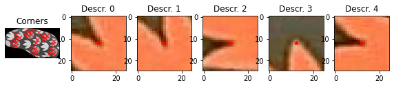

```python
# Here is some display to check the results
bb_id = 3
num_descr = 5
patch_half_size = 12
kpts = detect_harris_points(bubbles_gray[bb_id], min_distance=patch_half_size+1)
desc = compute_descriptors(bubbles[bb_id], kpts, wid=patch_half_size)
plt.figure(figsize=(10,4))
plt.subplot(1,num_descr+1,1)
plt.imshow(bubbles_gray[bb_id], cmap='gray')
plt.plot(kpts[:,1], kpts[:,0], 'x', c='r')
plt.axis("off")
plt.title("Corners")
for ii in range(min(num_descr, len(desc))):
    plt.subplot(1,num_descr+1,2+ii)
    dside = int(np.sqrt(desc[ii].shape[0]/3)) # recover the patch size
    plt.imshow(cv2.cvtColor(desc[ii].reshape((dside, dside, 3)), cv2.COLOR_BGR2RGB))
    plt.plot([dside//2], [dside//2], '*', c='r')
#     plt.axis('off')
    plt.title("Descr. %d" % ii)
```

## 3. Precompute the keypoints and their descriptors for all the bubbles

This will be useful for the next part, to accelerate the computation of the matching.

[figure not shown]

**Pre-compute all the keypoints and descriptors for all bubbles.** Tips: - Extract descriptors from regions of approximatively 25 per 25 pixels, separated at least by 10 pixels. - Others values may produce different results: you may want to come back here at the end of the session to try different extraction strategies.

```python
# TODO precompute keypoints and descriptors for all bubbles using `bubbles` and `bubbles_gray`
patch_half_size = 1  # FIXME
# list of list of keypoints for all bubbles: keypoints[i][j]: (np.array) keypoint j for bubbles_gray[i]
keypoints = []
# list of list of descriptors for all bubbles: descriptors[i][j]: (np.array) desc j for bubbles[i]
descriptors = []
# FIXME
print(len(keypoints), len(descriptors))
```

```
0 0
```

```python
# prof
patch_half_size = 25
keypoints = []
descriptors = []
for bb_color, bb_gray in zip(bubbles, bubbles_gray):
#     kpts = detect_harris_points(bb_gray, min_distance=patch_half_size+1)
    kpts = detect_harris_points(bb_gray, min_distance=10, threshold=0.1)
#     desc = compute_descriptors(bb_color, kpts, wid=patch_half_size)
    desc = compute_descriptors(bb_color, kpts, wid=12)
    keypoints.append(kpts)
    descriptors.append(desc)
print(len(keypoints), len(descriptors))
```

```
391 391
```

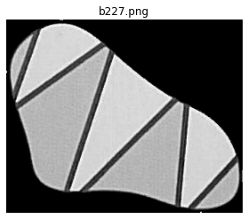

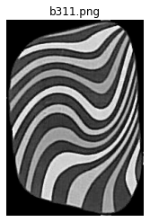

```python
# Sanity check: do we have bubbles without keypoints?
for ii, ki in enumerate(keypoints):
    if len(ki) == 0:
        plt.figure()
        plt.imshow(bubbles_gray[ii], cmap='gray')
        plt.axis('off')
        plt.title("b%03d.png" % (ii+1))
```

[figure not shown]

**Save the pre-computed keypoints and descriptors: we will use then in the next part.** Tips: - Save them somewhere on the network to save RAM (if working in EPITA's computers). - Use `np.savez_compressed` or any similar function to save objects.

```python
# save keypoints and descriptors somewhere
# TODO adapt this code to your actual parameters and variable names
# NOTE: we want to keep lists are we have unequal numbers of keypoints and descriptors for each bubble
# FIXME (Joseph): using joblib would be much better here

np.savez_compressed("results/kpts_descr_harris_25pxcolor_mdist10.npz",
                    descriptors=descriptors,
                    keypoints=keypoints)
# Check output
!ls -lh results/kpts_descr_harris_25pxcolor_mdist10.npz
```

```
-rw-r--r-- 1 jchazalo jchazalo 14M avril  5 12:13 results/kpts_descr_harris_25pxcolor_mdist10.npz
```

# Job done!

Now you're ready to move on to the next stage: Match keypoints and solve *Twin it!*.